# NBA Work Over Break

Brett Kornfeld

10/23/2019

## Data Read

```r
Nbastats <- read.csv(("C://Users/Tripl/OneDrive/Documents/R/nba.games.stats.csv"), stringsAsFactors = FALSE)
library(dplyr)
```

```r
library(ggplot2)
library(animation)
library(plotly)
library(gganimate)
```

## Create A Season Column and Win Column

```r
Nbastats<- Nbastats %>%
  mutate(Date = lubridate::as_date(Date),
         season = ifelse(Date > "2014-10-01" & Date < "2015-06-30", "2014-2015",
                      ifelse(Date > "2015-10-01" & Date < "2016-06-30", "2015-2016",
                            ifelse(Date > "2016-10-01" & Date < "2017-06-30", "2016-2017", "2017-2018"))),
         Win01= ifelse (WINorLOSS=="W", 1, 0))
```

Here I created a season column so as to help later in my analysis in sifting through season data. Due to changeovers in roster or coaches, individual seasons should be established for data integrity to be maintained. I also created a win loss column in order to later establish how many of the 82 games in a given season each individual team actually won.

## Create Effective Field Goal Percentage

```r
Nbastats <- Nbastats %>%
  mutate(EFGperc = (FieldGoals + (.5*X3PointShots))/FieldGoalsAttempted)
```

Effective field goal percentage is a statistic that bears more relevance then the regular field goal percentage because it accounts for the fact that a made three is worth more than a two point field-goal, despite that regular field goal percentage just weighs them all the same as “shots.”

## Summarize To Find Season Long Mean EFG% and Win-Loss Record

```r
 TeamSeasonEFG <- Nbastats %>%
    mutate(EFGperc = (FieldGoals + (.5*X3PointShots))/FieldGoalsAttempted) %>%
    group_by(Team, season) %>%
    summarize(meanEFG = mean(EFGperc), WinCount = sum(Win01), THREEPOINTSHOTSPERGAME = mean(X3PointShotsAttempted))
```

Here, I created a summary table of the data sorting by team and season in order to have the teams Effective FG% for the season and their wins in each seaosn.

## 30 Team Individual Breakdown Over Four Years

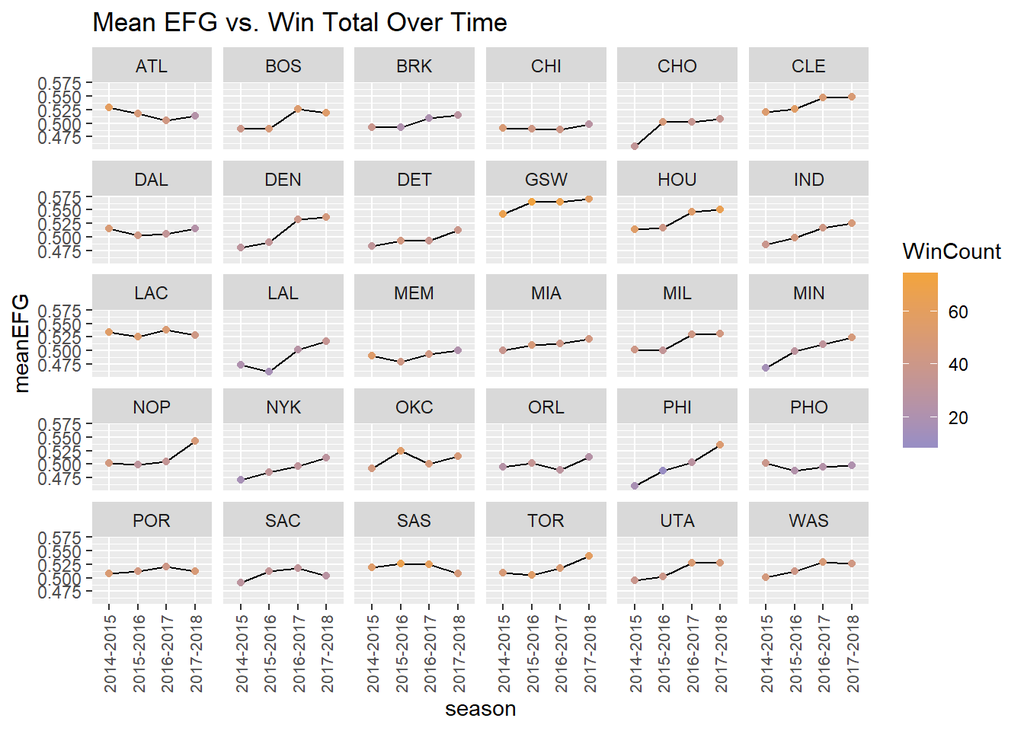

```r
 ThirtyTeamSplit <- ggplot(TeamSeasonEFG, aes(season, meanEFG, group=Team)) + geom_line()+
  geom_point(aes(color=WinCount)) +
   scale_color_gradient(low="#998ec3", high= "#f1a340")+
   facet_wrap(~Team) +
  theme(axis.text.x  = element_text(angle=90, vjust=0.5, size=8)) +
  ggtitle("Mean EFG vs. Win Total Over Time")

 ThirtyTeamSplit
```

## Moving Visual Of Mean EFG and Win Count from 2014/2015 - 2017-2018

```r
MovingWinTotalEFGNBAVIZ <- TeamSeasonEFG %>%
  plot_ly(
    x = ~meanEFG,
    y = ~WinCount,
    color = ~Team,
    frame = ~season,
    text = ~Team,
    hoverinfo = "text",
    type = 'scatter',
    mode = 'markers'
  ) %>%
  layout(
    xaxis = list(
      type = "log"
    )
  )

MovingWinTotalEFGNBAVIZ
```

[interactive chart not shown]

Similarly, this is a moving interactive graphic that lets you evaluate the team performance in EFG% and Win Total over the four seasons.

## Mean EFG vs. 3 Point Shots Attempted

# Sized for Win Count

```r
SizingWithThrees<- TeamSeasonEFG %>%
  plot_ly(
    x = ~meanEFG,
    y = ~THREEPOINTSHOTSPERGAME,
    size = ~WinCount,
    color = ~Team,
    frame = ~season,
    text = ~Team,
    hoverinfo = "text",
    type = 'scatter',
    mode = 'markers'
  ) %>%
  layout(
    xaxis = list(
      type = "log"
    )
  )

SizingWithThrees
```

[interactive chart not shown]

Here is a comparison of Mean EFG to 3 Point Shots Attempted, sizing the dots by win count in each season.